# ggplot2 Tips and Tricks and Extensions

## xgxr - Helper functions for plotting concentration data

`xgxr` is a package developed by Novartis (http://opensource.nibr.com/xgx/) for exploratory data analysis, particularly in the field of pharmacokinetic and pharmacodynamic data. Here we are only scratching the surface of this package but in particular I liked the ability to show minor grid lines on the log scale.

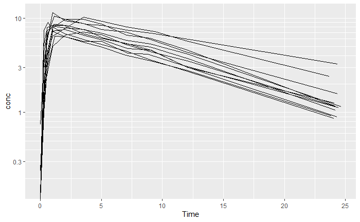

```r
library(xgxr)

ggplot(data = Theoph, mapping = aes(x = Time, y = conc, group = Subject)) +
  geom_line() +
  xgx_scale_y_log10()
```

### xgx_stat_ci - stat_summary with additional options for CI type

The `xgx_stat_ci` is very similar to functionality in the `stat_summary` geom (https://ggplot2.tidyverse.org/reference/stat_summary.html) but it extends this to allow the user to specify the confidence region width and the distribution of the outcome e.g. `normal`, `lognormal`, `binomial`.

In the code below we’re also using the `snap` function from the `metrumrg` package which snaps observed sample times to a nominal grid. This allows us to summarise observed values at their nominal times.

```r
times <- c(0, 0.25, 0.5, 1, 1.5, 2, 3.5, 5, 7, 9, 12, 24)
myTheoph <- Theoph %>%
  mutate(NTPD = metrumrg::snap(Time, times))
table(myTheoph$NTPD)
```

```
   0 0.25  0.5    1    2  3.5    5    7    9   12   24
  12   12   11   13   12   12   12   12   12   12   12
```

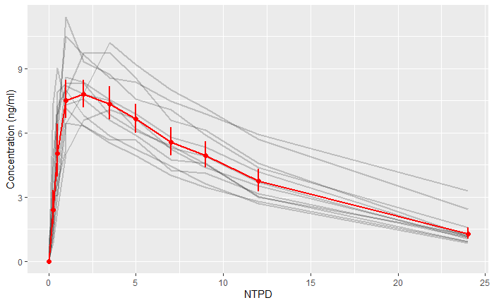

```r
theoPlot1 <- ggplot(data = myTheoph, aes(x = NTPD,y = conc)) +
  geom_line(mapping = aes(group = Subject), alpha=0.2) +
  xgx_stat_ci(color = "red", conf_level = 0.9, distribution = "lognormal") +
  labs(y = "Concentration (ng/ml)")
theoPlot1
```

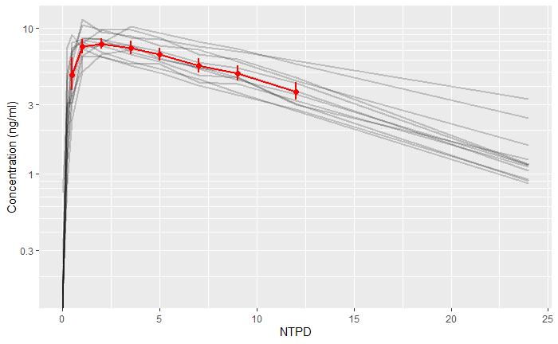

```r
theoPlot1 +
  xgx_scale_y_log10()
```

### xgx_scale_x_time_units - time units for x-axis scale

`xgxr` also has a useful function for working with time units on the x-axis. The function `xgx_scale_x_time_units` produces a label but also works out tick marks for the scale that are sensible given the units chosen.

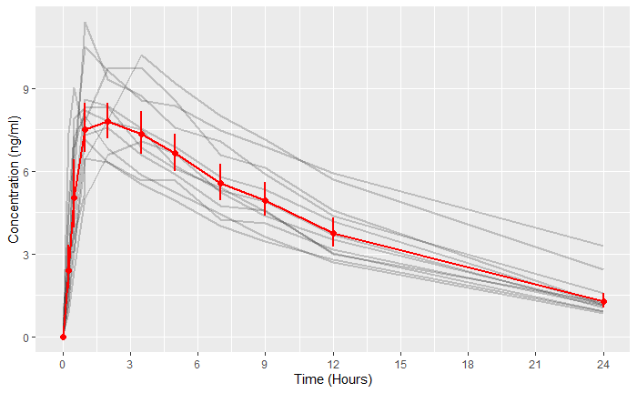

```r
theoPlot1 +
   xgx_scale_x_time_units(units_dataset = "h", units_plot = "h")
```

## survminer - Plotting survival curves

We’re now going to look at particular cases where the visualization of specialist data types produce `ggplot2` objects. The first is for survival data.

The `survminer` package (by Alboukadel Kassambara - https://rpkgs.datanovia.com/survminer/index.html) produces nice `ggplot2` visualizations of survival data including the number of subjects at risk within strata.

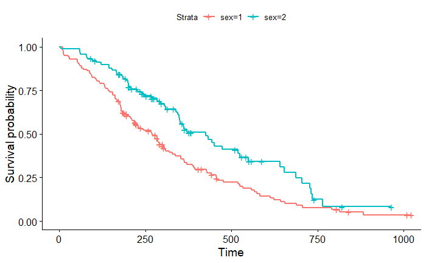

```r
library(survival)
library(survminer)
fit <- survfit(Surv(time, status) ~ sex, data = lung)
ggsurvplot(fit, data = lung)
```

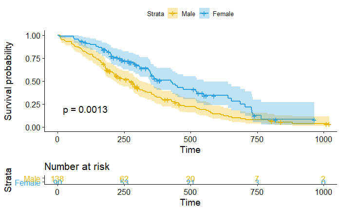

```r
ggsurvplot(
  fit,
  data = lung,
  size = 1,                 # change line size
  palette =
    c("#E7B800", "#2E9FDF"),# custom color palettes
  conf.int = TRUE,          # Add confidence interval
  pval = TRUE,              # Add p-value
  risk.table = TRUE,        # Add risk table
  risk.table.col = "strata",# Risk table color by groups
  legend.labs =
    c("Male", "Female"),    # Change legend labels
  risk.table.height = 0.25 # Useful to change when you have multiple groups
)
```

## ggraph - Visualizing networks

`ggraph` (by Thomas Lin Pedersen - https://ggraph.data-imaginist.com/) produces visualizations of networks. Here we visualize the relationships and dependencies associated with the `tidyverse` package, based on the `miniCRAN` package function `makeDepGraph` and the `tidygraph` and `ggraph` packages. Note that `ggraph` uses `repel` functionality in `geom_node_text` to present tidy labels in the visualization.

[figure not shown]

```r
library(miniCRAN)
library(ggraph)
library(tidygraph)

tidyverseDependencies <- makeDepGraph(pkg = "tidyverse") %>%
  as_tbl_graph()

ggraph(tidyverseDependencies, layout = "graphopt") +
  geom_node_point() +
  geom_edge_link(aes(colour = type)) +
  geom_node_text(aes(label = name),
                 repel = TRUE)
```

## Save all ggplot2 objects to working directory

Finally, here’s one I produced (by Mike K Smith!). This snippet of code picks out all objects in the environment that have type `gg` in their object class i.e. likely `ggplot2` objects or objects that are associated with `ggplot2` object types. It then writes each object individually to an externalised `.Rdata` object. This allows you to read each object in individually and edit or add to it as discussed above. So rather than running many lines of code to reproduce the graphic, only to change one line, you can read in the object, alter or add to it, then render as `.png` file.

```r
plotObjects <- Filter( function(x) 'gg' %in% class( get(x) ), ls() )

## Save plot objects individually
sapply(plotObjects, function(x)saveRDS(object = get(x), file = paste0(x,".Rdata",sep="")))

## reload individually
# plot1 <- readRDS("plot1.Rdata")

# Save all plots as one object
# save(list = plotObjects, file = "plots.Rdata")

## test reloading
# remove(list = ls())
# load("plots.Rdata")
```